# Correción: Trabajo Diagrama de Lexis

*Por Cristian Baeza Torres*

• Defina las variables que toma en cuenta el diagrama de Lexis. (Eje X, Eje Y) (2 ptos)  
*Respuesta* : El diagrama de lexis toma en cuenta dos variables **El Tiempo** y **La duración del fenomeno que se quiere analizar**. En el gráfico en el **Eje X** va el *Tiempo calendario en años* y en el **Eje Y** va la *Edad en años*.

**Ejemplo:**

[figure not shown]

• ¿Qué implica la salida o entrada de un individuo en un diagrama de Lexis? (3 ptos)  
La salida de un individuo significa que este salio de la población por alguna causa como muerte o migración. Es decir, dejo de pertenecer a la población. La entrada es lo contrario, es cuando un individuo nace o entra (inmigrando) a la población.

• Dibuje un diagrama de Lexis desde el año 1999 al año 2004 partiendo desde 0 a 5 años. (3 ptos)

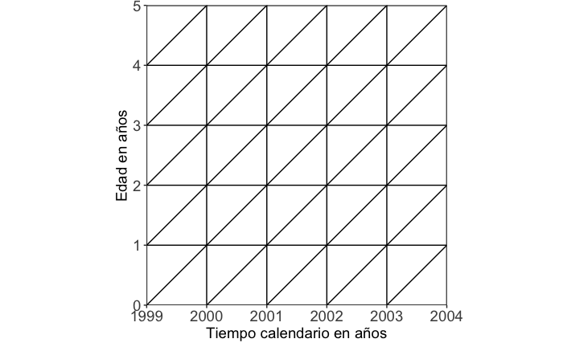

• Dibuje una línea de vida de un individuo que nació el 1 de enero del 2000. ¿Cuál es su Cohorte? ¿Qué edad tenia para el año 2003? (5 ptos)  
El Cohorte esta indicado en color verde y es el del año 2000. En el año 2003 tiene 3 años, ya que cumple años el 1 de enero.

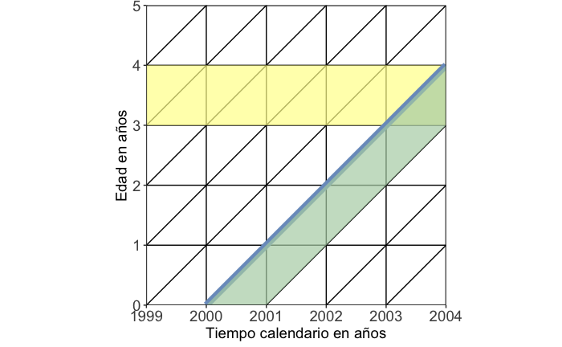

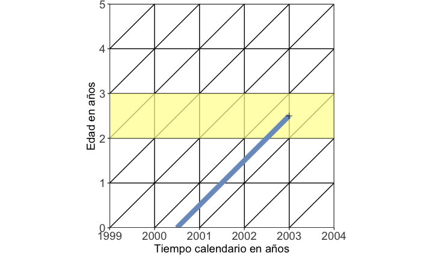

• Dibuje un diagrama desde el año 2012 hasta el año 2020. Comenzando de los 15 años hasta los 22. (5 ptos)

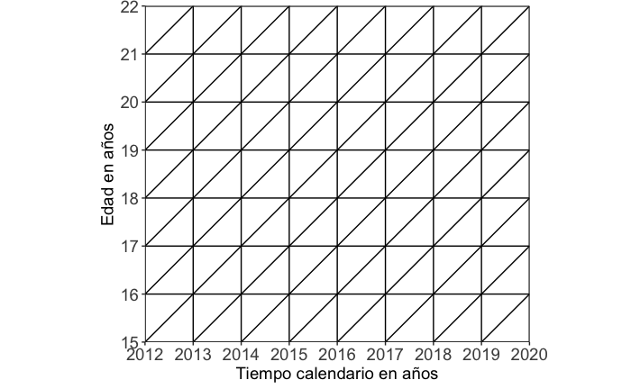

• En el diagrama anterior, dibuje una línea de vida de un individuo que nació el 10 de mayo de 1997. ¿Cuál es su cohorte? Marque en otro color. ¿Qué edad tiene en el 2012? ¿Qué edad tiene al 2019? (5 ptos)

[figure not shown]

[figure not shown]

Dudas o consultas al mail del ayudante **cbaeza2016@udec.cl** o **crisbaezatorres@gmail.com**  
Los diagramas fueron realizados en R, si desea ver el código de este elemento solicitarlo al mail. ***